# CIND 123 - Data Analytics: Basic Methods

Karnaz Obaidullah

# Assignment 1 (10%)

### CIND123 Section DHD 501000900

# Instructions

Use RStudio for this assignment. Complete the assignment by inserting your code wherever you see the string “#INSERT YOUR ANSWER HERE”.

**NOTE**: YOU SHOULD NEVER HAVE `install.packages` IN YOUR CODE; OTHERWISE, THE `Knit` OPTION WILL GIVE AN ERROR. COMMENT OUT ALL PACKAGE INSTALLATIONS.

Submit **both** the `rmd` and generated `output` files. Failing to submit both files will be subject to mark deduction. PDF or HTML is preferred.

## Sample Question and Solution

Use `seq()` to create the vector $(3,5\ldots,29)$.

```r
seq(3, 30, 2)
```

```
##  [1]  3  5  7  9 11 13 15 17 19 21 23 25 27 29
```

```r
seq(3, 29, 2)
```

```
##  [1]  3  5  7  9 11 13 15 17 19 21 23 25 27 29
```

## Question 1 (32 points)

## Q1a (8 points)

Create and print a vector `x` with all integers from 15 to 100 and a vector `y` containing multiples of 5 in the same range. Hint: use `seq()`function. Calculate the difference in lengths of the vectors `x` and `y`. Hint: use length()

```r
x <- seq(15, 100)
y <- seq(15, 100, 5)
length(x) - length(y)
```

```
## [1] 68
```

## Q1b (8 points)

Create a new vector, `x_square`, with the square of elements at indices 1, 11, 21, 31, 41, 51, 61, and 71 from the variable `x`. Hint: Use indexing rather than a `for` loop. Calculate the mean and median of the FIRST five values from `x_square`.

```r
x_square <- c(x[1],x[11], x[21], x[31], x[41], x[51], x[61], x[71])^2
mean(x_square[1:5])
```

```
## [1] 1425
```

```r
median(x_square[1:5])
```

```
## [1] 1225
```

## Q1c (8 points)

For a given factor variable of `factorVar <- factor(c(10.8, 2.7, 5.0, 3.5))`. To convert the factor to number, you need to either: 1) use `level()` to extract the level labels, then use `as.numeric()` to convert the labels to numbers, or 2) use `as.charactor()` to convert the values in the factorVar, then use `as.numeric()` to convert the values to numbers

Please provide both solutions

```r
factorVar <- factor(c(10.8, 2.7, 5.0, 3.5))

as.numeric(levels(factorVar))
```

```
## [1]  2.7  3.5  5.0 10.8
```

```r
as.numeric(as.character(factorVar))
```

```
## [1] 10.8  2.7  5.0  3.5
```

## Q1d (8 points)

A comma-separated values file `dataset.csv` consists of missing values represented by Not A Number (`null`) and question mark (`?`). How can you read this type of files in R? NOTE: Please make sure you have saved the `dataset.csv` file at your current working directory.

```r
read.csv("dataset.csv", na.strings=c("?", "null"))
```

```
##     X1  X2  X3  X4  X5  X6  X7  X8  X9 X10
## 1   11  12  13  14  15  16  17  18  19  20
## 2   21  22  23  24  25  26  27  28  29  30
## 3   31  32  33  34  35  36  37  38  39  40
## 4   41  42  43  44  45  NA  47  48  49  50
## 5   51  52  53  NA  55  56  57  NA  59  60
## 6   61  62  63  64  65  66  67  68  69  70
## 7   71  72  NA  74  75  76  77  78  79  80
## 8   81  82  83  84  85  86  87  88  89  NA
## 9   91  92  93  94  95  96  97  98  99 100
## 10  NA 102 103 104 105 106 107 108 109 110
## 11 111 112 113 114 115 116 117 118 119 120
## 12 121 122 123 124 125 126 127 128 129 130
## 13 131 132 133 134 135 136 137 138 139  NA
## 14 141 142 143 144 145 146 147 148 149 150
## 15 151 152 153 154 155 156 157 158 159 160
## 16 161 162 163 164  NA 166 167 168 169 170
```

# Question 2 (32 points)

## Q2a (8 points)

Compute:
$$\frac{1}{4!}
\sum_{n=10}^{40}3^{n}$$
Hint: Use `factorial(n)` to compute $n!$.

```r
sample_func <- function(n){
    3 ^ n
}
n_max <- 40
n_min <- 10

sequence_of_n <- c(n_min: n_max)

(1/factorial(4)) * sum(sample_func(sequence_of_n))
```

```
## [1] 7.598541e+17
```

## Q2b (8 points)

Compute:
$$\prod_{n=1}^{20} \left( 3n +
\frac{1}{n} \right)$$
NOTE: The symbol $\Pi$ represents multiplication.

```r
result <- 1

for (n in 1:20){
  y <- 3*n + 1/n

  result <- result * y
}

result
```

```
## [1] 1.373708e+28
```

## Q2c (8 points)

Describe what the following R command does: `c(0:5)[NA]`

```r
c(0:5)[NA]
```

```
## [1] NA NA NA NA NA NA
```

## Q2d (8 points)

Describe the purpose of `is.vector()`, `is.character()`, `is.numeric()`, and `is.na()` functions? Please use `x <- c("a","b",NA,2)` to explain your description.

```r
x <- c("a","b",NA,2)

is.vector(x)
```

```
## [1] TRUE
```

```r
is.character(x)
```

```
## [1] TRUE
```

```r
is.numeric(x)
```

```
## [1] FALSE
```

```r
is.na(x)
```

```
## [1] FALSE FALSE  TRUE FALSE
```

is.vector() determines whether object is vector is.character() determines whether object is of character data type is.numeric() determines whether object is of numeric data type is.na() determines whether object has null values

# Question 3 (36 points)

The `airquality` dataset contains daily air quality measurements in New York from May to September 1973. The variables include Ozone level, Solar radiation, wind speed, temperature in Fahrenheit, month, and day. Please see the detailed description using `help("airquality")`.

```r
help("airquality")
```

Install the `airquality` data set on your computer using the command `install.packages("datasets")`. Then load the `datasets` package into your session.

```r
#library(datasets)
```

## Q3a (4 points)

Display the first 6 rows of the `airquality` data set.

```r
head(airquality)
```

```
##   Ozone Solar.R Wind Temp Month Day
## 1    41     190  7.4   67     5   1
## 2    36     118  8.0   72     5   2
## 3    12     149 12.6   74     5   3
## 4    18     313 11.5   62     5   4
## 5    NA      NA 14.3   56     5   5
## 6    28      NA 14.9   66     5   6
```

## Q3b (8 points)

Compute the average of the first four variables (Ozone, Solar.R, Wind and Temp) for the fifth month using the `sapply()` function. Hint: You might need to consider removing the `NA` values; otherwise, the average will not be computed.

```r
filtered <- na.omit(airquality[airquality$Month == 5, ])

average <- sapply(filtered[, 1:4], mean)

average
```

```
##     Ozone   Solar.R      Wind      Temp
##  24.12500 182.04167  11.50417  66.45833
```

## Q3c (8 points)

Construct a boxplot for the all `Wind` and `Temp` variables, then display the values of all the outliers which lie beyond the whiskers.

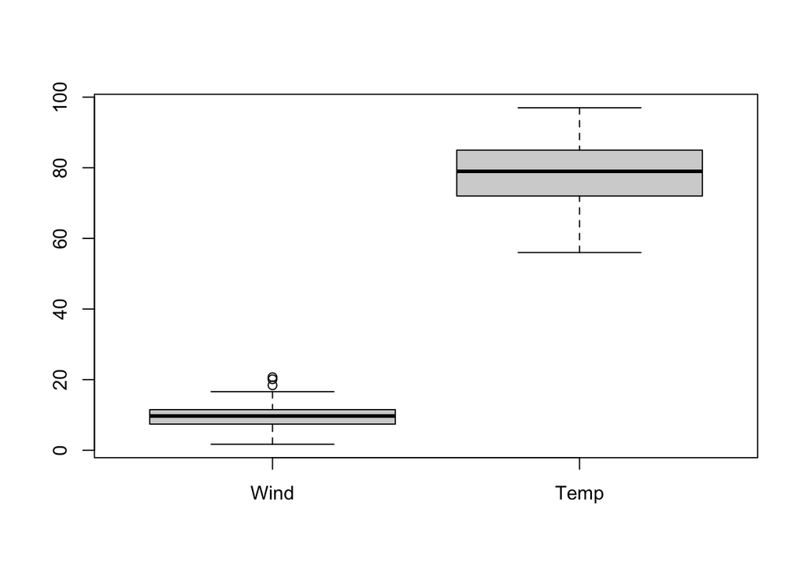

```
## integer(0)
```

```r
boxplot(airquality$Wind, airquality$Temp, names = c("Wind", "Temp"))

outliers <- boxplot(airquality$Wind, airquality$Temp, plot = FALSE)$out

identify(outliers, labels = outliers)
```

## Q3d (8 points)

Compute the upper quartile of the `Wind` variable with two different methods. HINT: Only show the upper quartile using indexing. For the type of quartile, please see https://www.rdocumentation.org/packages/stats/versions/3.6.2/topics/quantile.

```r
# Method 1
upper_quartile1 <- quantile(airquality$Wind, probs = 0.75)
upper_quartile1
```

```
##  75%
## 11.5
```

```r
# Method 2
sort_wind <- sort(airquality$Wind)
n <- length(sort_wind)
index <- ceiling(0.75 * n)
upper_quartile2 <- sort_wind[index]
upper_quartile2
```

```
## [1] 11.5
```

## Q3e (8 points)

Construct a pie chart to describe the number of entries by `Month`. HINT: use the `table()` function to count and tabulate the number of entries within a `Month`.

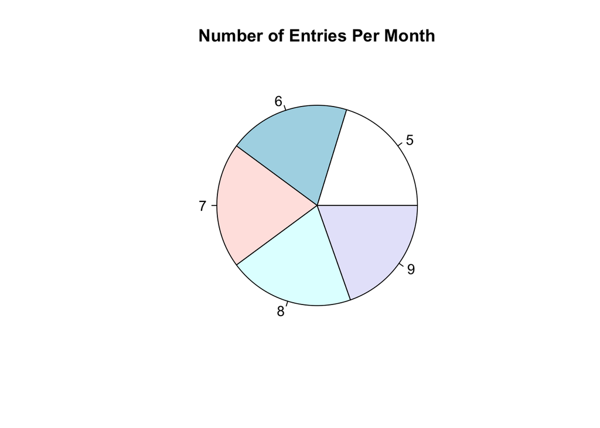

```r
entries_per_month <- table(airquality$Month)

pie(entries_per_month, labels = names(entries_per_month), main="Number of Entries Per Month")
```

END of Assignment #1.